# Data Storytelling

08-05-2021

## Qué veremos hoy?

- Contexto:
  - Qué es Data Storytelling
  - Cuando usarlo
  - Ejemplos (pocos! y rápidos!) en comunicación masiva
- Data Storytelling
  - Lecciones en Data Storytelling
  - **Ejemplo (largo! detallado!) de Storytelling en contexto de negocios**
- Cierre

## Qué es Data Storytelling?

**Lecciones narrativas + comunicación de datos**

- Lecciones narrativas:
  - Cómo estructurar la historia
  - Cómo hacer que recuerden tu historia
- Comunicación de datos efectiva
  - Nivel de detalle acorde a la audiencia y al contexto
  - Cómo las personas consumen información?

## Necesito Data Storytelling?

- Necesidad alta: capturar audiencia, inducir una acción, audiencia no experta, situación Big Idea, periodismo de datos, comunicación masiva
- Necesidad media: audiencia cautiva, indicadores rutinarios, audiencia experta, future-proofing
- Baja necesidad: análisis exploratorio, almacenamiento de datos, auditoría

## Data Storytelling en negocios

- Primera asociación es con periodismo de datos, audiencias masivas
- Sin embargo, es muy útil en contextos de negocios
  - audiencia con tiempo limitado
  - audiencia debe escuchar presentaciones que no son de su especialidad
  - interacciones dedicadas a la toma de decisiones
- Énfasis difieren, conjunto de lecciones es similar

## Ejemplo: equipo de atención al cliente

- Equipo de especialistas en Mesa de Ayuda (EMAs). Reciben y procesan órdenes (“tickets”)
- Dos miembros se fueron. Hay atrasos en el procesamiento de los tickets.
- La gerencia tomó nota del atraso. Te llaman, como jefe de equipo, a una reunión informativa.
- Tu objetivo: mejorar imagen de tu equipo y conseguir refuerzos.

## Primer impulso: mostrar los datos

Tickets de servicio: datos de procesados versus recibidos

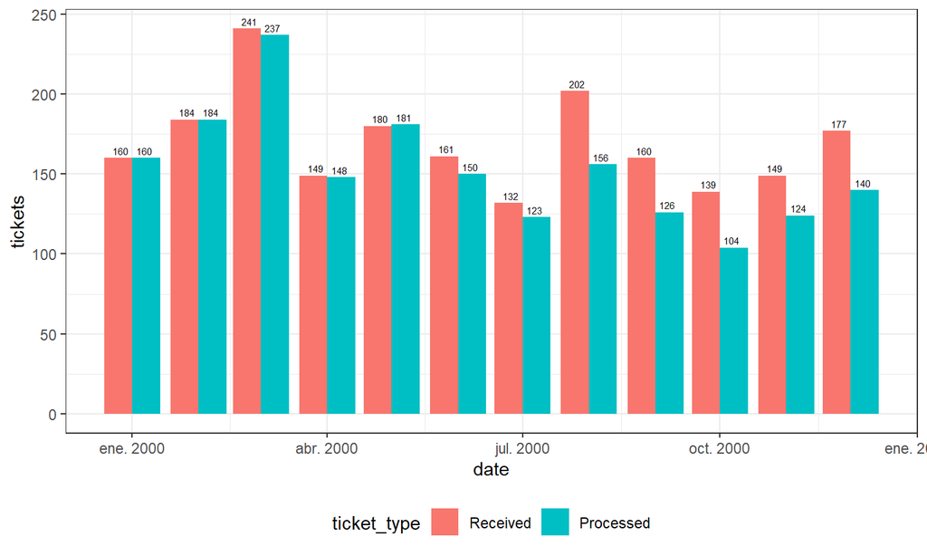

## Forma sigue a la función

Tendencia y brechas: líneas es mejor que barras.

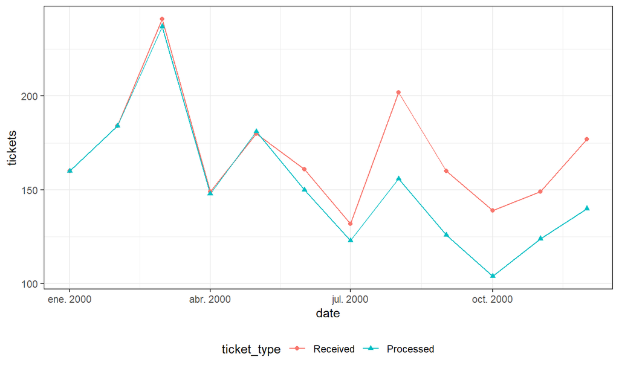

## Llama a Marie Kondo, bota cachureos

Remover líneas verticales, horizontales y marcadores de datos

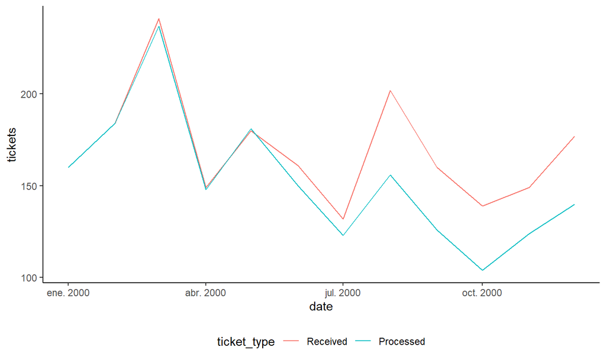

## **Anotar** es mejor que *legendar*

Leyendas suelen distraer y requieren más esfuerzo cognitivo

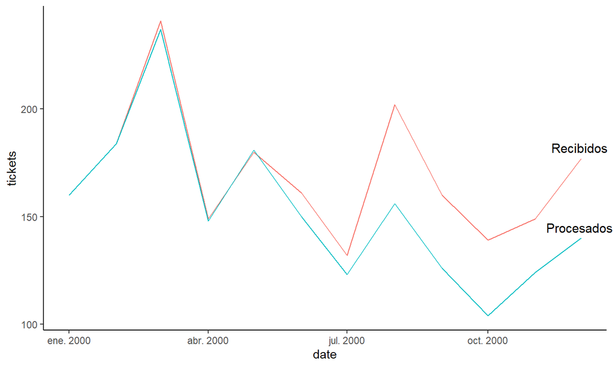

## Use el color para reforzar

Colores ya asociados a Recibidos y Procesados. Mantenerlo así.

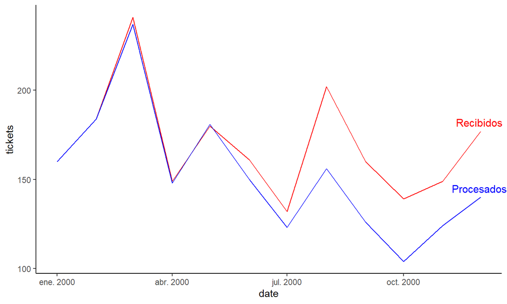

## Concentre la atención

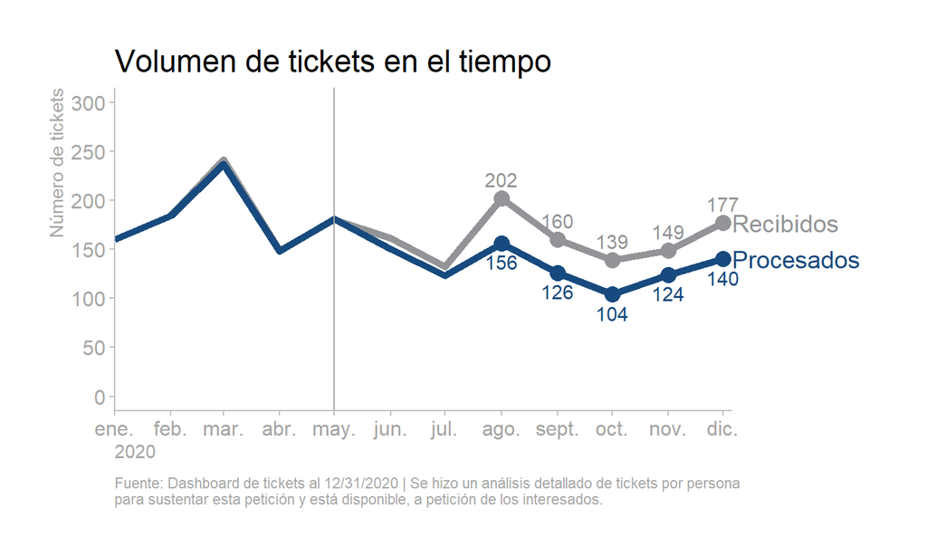

## Entregue un contexto

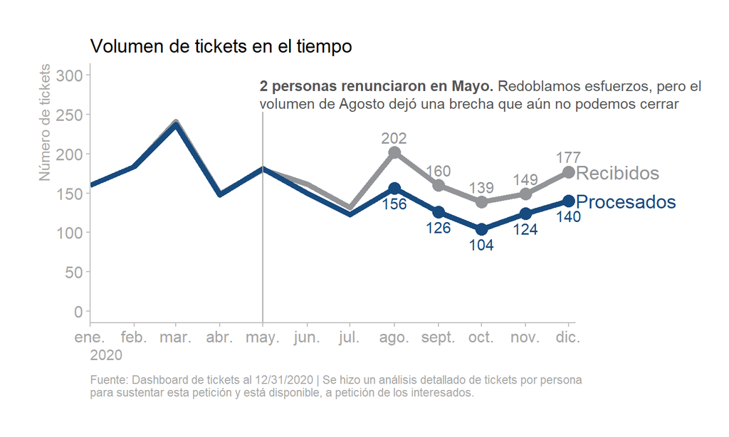

## Quiere algo? Pídalo!

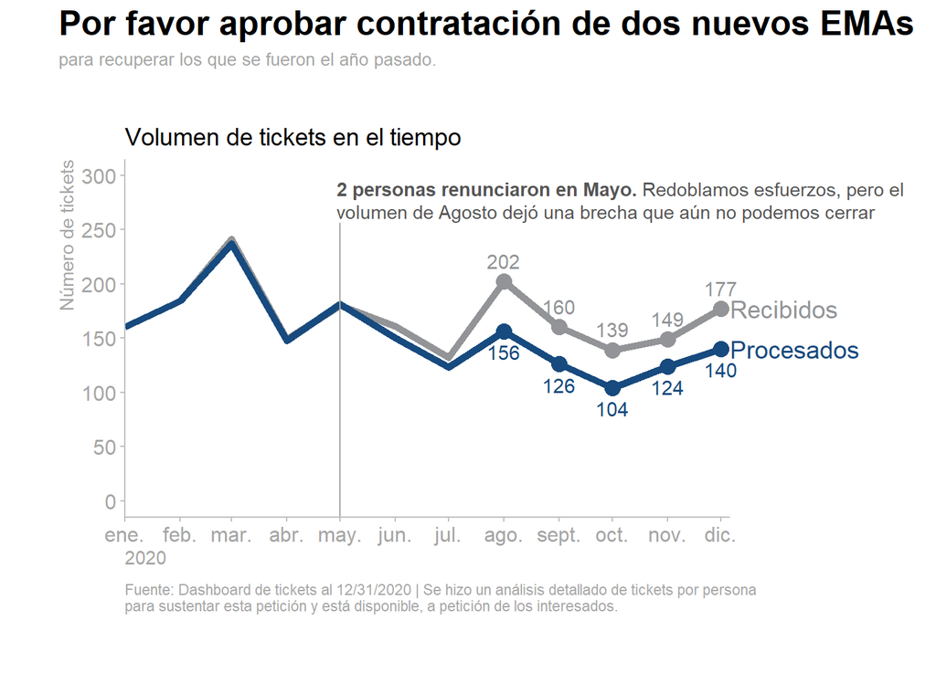

## Lecciones en Data Storytelling

- Contexto: quién, qué, cómo?
- Elementos visuales más efectivos
- Botar cachureos
- Concentrar y guiar la atención
- Asegurar el mensaje

## DST en comunicación masiva (I)

FiveThirtyEight: cómo cambió USA durante Obama?

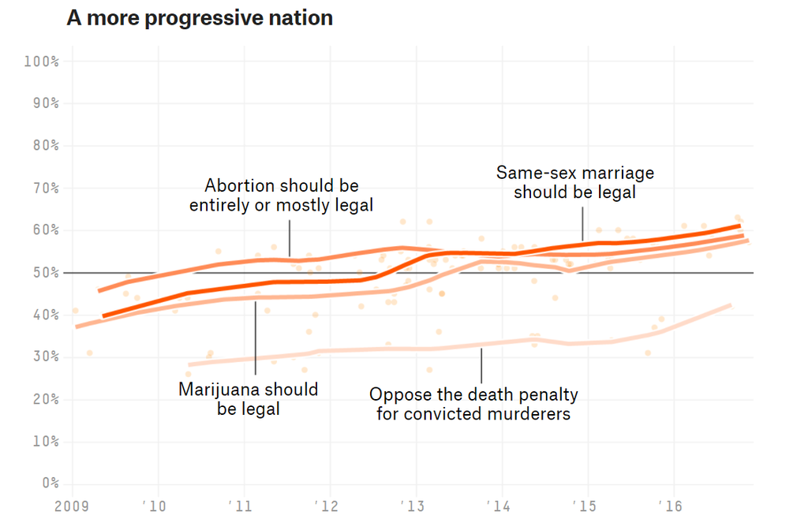

## DST en comunicación masiva (II)

ProPública: trabajo y racismo en USA

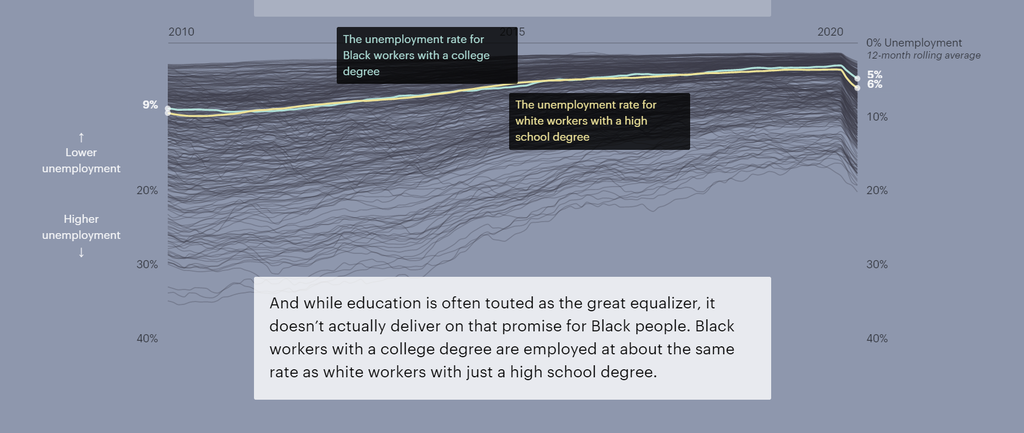

## Herramientas/Aprendizaje

- Estas lecciones **no** dependen de la herramienta escogida
- Dicho eso, necesita aprender al menos una :-)
- **Ven a aprender Data Storytelling con nosotros!**
  - Datos + Herramientas + Historias
- Este webinar: **todo** hecho desde `R`
  - Gráficos: ggplot2
  - Presentación: ioslides + RMarkdown
- Código y presentación disponible aquí: https://github.com/ricardomayerb/webinar-data-st-viz

## Créditos

- Ejemplo original de Cole Nussbaumer Knaflic, en Storytelling with Data.
- Código R creado a partir del código de Adam Ribaudo

## Gracias!!

- Bueno, eso es todo :-)
- Preguntas?